# Case Study 2

Group 97 - Data manipulation

Beccard, Leon - 12133103

Farmohammadi, Pouya - 52116495

Monteiro Oliveira, Guilherme - 12243299

2024-05-10

# Tasks

## Task a

We are loading the data that was available in TUWEL and we should keep the country names and the variables.

```r
#Get current directory

df_median <- read_fwf("./rawdata_343.txt",
                      skip = 2,
                      fwf_widths(c(8, 66, 12, NA),
                                 c("Id", "Country", "Median age", "Note"))) %>%
  select(Country, `Median age`)
df_net <- read_fwf("./rawdata_347.txt",
                   skip = 2,
                   fwf_widths(c(8, 64, 6, NA),
                              c("Id", "Country", "Net migration rate", "Note"))) %>%
  select(Country, `Net migration rate`)
df_uempl <- read_csv("./rawdata_373.csv") %>%
  rename("Country" = country_name,
         "youth unemployed rate" = youth_unempl_rate)
```

## Task b

The following code is merging the datasets using the key *Country*.

```r
df <- df_median %>%
  full_join(df_net, by = "Country") %>%
  full_join(df_uempl, by = "Country")

str(df)
```

```
## tibble [227 × 4] (S3: tbl_df/tbl/data.frame)
##  $ Country              : chr [1:227] "Monaco" "Japan" "Saint Pierre and Miquelon" "Germany" ...
##  $ Median age           : num [1:227] 55.4 48.6 48.5 47.8 46.5 46.2 45.6 45.6 45.3 45.2 ...
##  $ Net migration rate   : num [1:227] 8.3 0 -7.7 1.5 3.2 0 1.7 -3 0.9 6.6 ...
##  $ youth unemployed rate: num [1:227] 26.6 3.6 NA 6.2 32.2 NA 8.7 NA 39.9 27.4 ...
```

## Task c

Acquiring data from the link https://datahelpdesk.worldbank.org/knowledgebase/articles/906519

```r
url <- "https://datacatalogfiles.worldbank.org/ddh-published/0037712/DR0090755/CLASS.xlsx"
destfile <- "CLASS.xlsx"

download.file(url, destfile)

df_country_group <- read_xlsx('./CLASS.xlsx', sheet = 1)

str(df_country_group)
```

```
## tibble [267 × 5] (S3: tbl_df/tbl/data.frame)
##  $ Economy         : chr [1:267] "Aruba" "Afghanistan" "Angola" "Albania" ...
##  $ Code            : chr [1:267] "ABW" "AFG" "AGO" "ALB" ...
##  $ Region          : chr [1:267] "Latin America & Caribbean" "South Asia" "Sub-Saharan Africa" "Europe & Central Asia" ...
##  $ Income group    : chr [1:267] "High income" "Low income" "Lower middle income" "Upper middle income" ...
##  $ Lending category: chr [1:267] NA "IDA" "IBRD" "IBRD" ...
```

## Task d

1. Common variable

```r
check1 <- df %>% left_join(df_country_group, by = c("Country" = "Economy"))

check1["Income group"] %>% is.na() %>% sum()
```

```
## [1] 41
```

Here the common variable is Country and Economy. It is possible to merge them, from the 227 countries. 41 countries were not found.

2. ISO Codes

The data was manually downloaded using the link https://www.cia.gov/the-world-factbook/references/country-data-codes/

```r
codes <- read_csv("./Country\ Data\ Codes.csv")
```

3. Reliable Merge

```r
reliable_merge <- df %>%
  left_join(codes, by = c("Country" = "Name")) %>%
  left_join(df_country_group, by = c("GENC" = "Code"))

reliable_merge %>% select(Country, GENC, "Median age", "Net migration rate",
                          "youth unemployed rate", "Income group")
```

```
## # A tibble: 227 × 6
##    Country        GENC  `Median age` `Net migration rate` youth unemployed rat…¹
##    <chr>          <chr>        <dbl>                <dbl>                  <dbl>
##  1 Monaco         MCO           55.4                  8.3                   26.6
##  2 Japan          JPN           48.6                  0                      3.6
##  3 Saint Pierre … SPM           48.5                 -7.7                   NA
##  4 Germany        DEU           47.8                  1.5                    6.2
##  5 Italy          ITA           46.5                  3.2                   32.2
##  6 Andorra        AND           46.2                  0                     NA
##  7 Hong Kong      HKG           45.6                  1.7                    8.7
##  8 Saint Barthel… BLM           45.6                 -3                     NA
##  9 Greece         GRC           45.3                  0.9                   39.9
## 10 San Marino     SMR           45.2                  6.6                   27.4
## # ℹ 217 more rows
## # ℹ abbreviated name: ¹`youth unemployed rate`
## # ℹ 1 more variable: `Income group` <chr>
```

```r
reliable_merge["Income group"] %>% is.na() %>% sum()
```

```
## [1] 15
```

Using this approach we got only 15 missing values. What is corresponding to finding 26 countries more with this new approach instead of the one before.

## Task e

To add the regions to our dataset the data was obtained from https://statisticstimes.com/geography/countries-by-continents.php.

```r
regions <- read_csv("./country_region_continent.csv")
df_vars <- reliable_merge %>%
  left_join(regions, by = c(GENC = "ISO-alpha3 Code")) %>%
  select(Country, "Median age", "Net migration rate", "youth unemployed rate",
         "Income group", "Region 1", "Continent")
str(df_vars)
```

```
## tibble [227 × 7] (S3: tbl_df/tbl/data.frame)
##  $ Country              : chr [1:227] "Monaco" "Japan" "Saint Pierre and Miquelon" "Germany" ...
##  $ Median age           : num [1:227] 55.4 48.6 48.5 47.8 46.5 46.2 45.6 45.6 45.3 45.2 ...
##  $ Net migration rate   : num [1:227] 8.3 0 -7.7 1.5 3.2 0 1.7 -3 0.9 6.6 ...
##  $ youth unemployed rate: num [1:227] 26.6 3.6 NA 6.2 32.2 NA 8.7 NA 39.9 27.4 ...
##  $ Income group         : chr [1:227] "High income" "High income" NA "High income" ...
##  $ Region 1             : chr [1:227] "Western Europe" "Eastern Asia" "Northern America" "Western Europe" ...
##  $ Continent            : chr [1:227] "Europe" "Asia" "North America" "Europe" ...
```

## Task f

Discuss on the tidyness of the data set df_vars. What are the observational units, what are the variables? What can be considered fixed vs measured variables? Tidy the data if needed.

#### Observational units and variables

The observational unit is a country. Each row in the dataset represents one country. The variables in the dataset are:

- Country: The name of the country (character variable).
- Median age: The median age of the population in that country (numeric variable).
- Net migration rate: The net migration rate of the country (numeric variable).
- youth unemployed rate: The youth unemployment rate in the country (numeric variable).
- Income group: The income group the country belongs to (character variable).
- Region 1: The region the country belongs to (character variable).
- Continent: The continent the country belongs to (character variable).

#### Fixed vs Measured Variables

**Fixed variables:** Variables that are constant for a given country, such as Country, Income group, Region 1, and Continent.  
**Measured variables:** Variables that measure some attribute of the country and can vary over time, such as Median age, Net migration rate, and youth unemployed rate.

#### Tidying the data

**1. Improve and standardize the column names**  
The column names have no consistency in their names. Some are lowercase, some are uppercase. Also spaces in between is bad practice and underscores are preferred instead. This will be changed by adding underscores instead of spaces and by lowercasing every name. Also “Region 1” is misleading since there is only one region column. So this will be changed to Region.

```r
# Rename column 'Region 1' to 'Region'
names(df_vars)[names(df_vars) == "Region 1"] <- "Region"

# Lowercase each column name
names(df_vars) <- tolower(names(df_vars))

# Replace spaces with underscores in column names
names(df_vars) <- gsub(" ", "_", names(df_vars))
str(df_vars)
```

```
## tibble [227 × 7] (S3: tbl_df/tbl/data.frame)
##  $ country              : chr [1:227] "Monaco" "Japan" "Saint Pierre and Miquelon" "Germany" ...
##  $ median_age           : num [1:227] 55.4 48.6 48.5 47.8 46.5 46.2 45.6 45.6 45.3 45.2 ...
##  $ net_migration_rate   : num [1:227] 8.3 0 -7.7 1.5 3.2 0 1.7 -3 0.9 6.6 ...
##  $ youth_unemployed_rate: num [1:227] 26.6 3.6 NA 6.2 32.2 NA 8.7 NA 39.9 27.4 ...
##  $ income_group         : chr [1:227] "High income" "High income" NA "High income" ...
##  $ region               : chr [1:227] "Western Europe" "Eastern Asia" "Northern America" "Western Europe" ...
##  $ continent            : chr [1:227] "Europe" "Asia" "North America" "Europe" ...
```

**Step 2 Removing missing values** There are severals missing values (NAs) in the variables `income_group` and `youth_unemployed_rate`. Imputing missing values correctly is quite sophisticated and can mislead to results by simply using the median or mean or a specific value. Therefore, we simply remove the rows i.e. countries that have missing values.

```r
df_vars_cleaned <- na.omit(df_vars)
nrow(df_vars)
```

```
## [1] 227
```

```r
nrow(df_vars_cleaned)
```

```
## [1] 175
```

```r
df_vars <- df_vars_cleaned
```

As given, there only 175 countries listed in the dataframe anymore.

**Step 3: Standardizing and factorizing columns**  
The variables `income_group`, `region` and `continent` can be standardized by lowercasing each variable, removing the whitespaces and converting them to factors since they are categorical variables.

```r
df_vars$income_group <- tolower(trimws(df_vars$income_group))
df_vars$region <- tolower(trimws(df_vars$region))
df_vars$continent <- tolower(trimws(df_vars$continent))
df_vars$income_group <- factor(df_vars$income_group)
df_vars$region <- factor(df_vars$region)
df_vars$continent <- factor(df_vars$continent)
head(df_vars[c("income_group", "region", "continent")], 10)
```

```
## # A tibble: 10 × 3
##    income_group region          continent
##    <fct>        <fct>           <fct>
##  1 high income  western europe  europe
##  2 high income  eastern asia    asia
##  3 high income  western europe  europe
##  4 high income  southern europe europe
##  5 high income  eastern asia    asia
##  6 high income  southern europe europe
##  7 high income  southern europe europe
##  8 high income  southern europe europe
##  9 high income  northern europe europe
## 10 high income  southern europe europe
```

## Task g

Make a frequency table for the status variable in the merged data set. Briefly comment on the results.

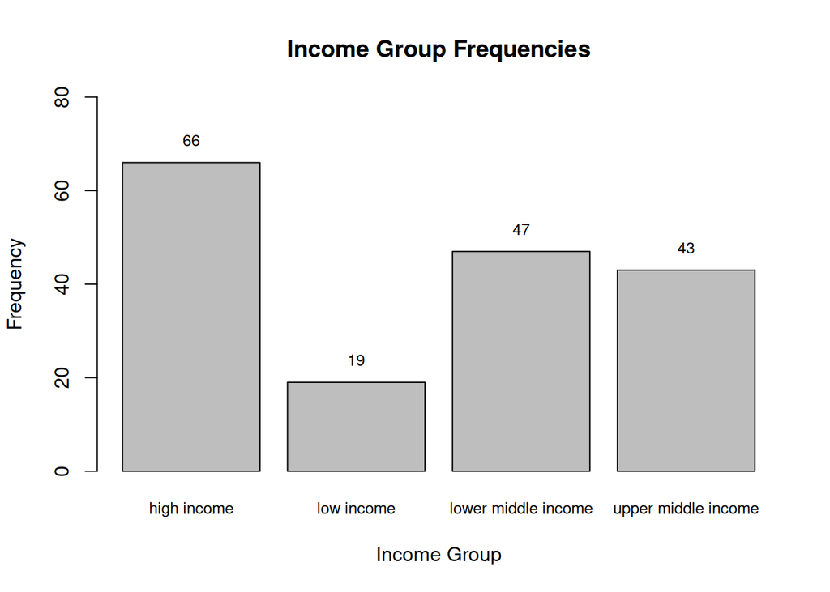

```r
income_group_frequency_table <- table(df_vars$income_group)
# Create the barplot
bp <- barplot(income_group_frequency_table, main = "Income Group Frequencies",
              xlab = "Income Group", ylab = "Frequency", ylim=c(0,80), cex.names = 0.8)

# Add text above each bar to display the frequency
text(x = bp, y = income_group_frequency_table + 1,
     labels = income_group_frequency_table, pos = 3, cex = 0.8, col = "black")
```

As shown in the barplot, most countries are represented by the higher income group, mainly 66 and only 19 countries belong to the low income group.

## Task h

Note: This [post](https://stackoverflow.com/a/62140681/19932351) helped to understand, why to use `.groups = 'drop'` to avoid the mentioned error in the post.

```r
# Group data by continent and income group
income_distribution <- df_vars %>%
  group_by(continent, income_group) %>%
  summarise(
    absolute_freq = n(),
    .groups = 'drop'
  ) %>%
  # Calculate the total number of countries per continent
  group_by(continent) %>%
  mutate(
    total_countries_in_continent = sum(absolute_freq),
    # Calculate the relative frequency of each income group within each continent
    relative_freq = absolute_freq / total_countries_in_continent * 100
  ) %>%
  # Select to drop the 'total_countries_in_continent' variable
  select(-total_countries_in_continent)

# Print the income distribution
print(income_distribution)
```

```
## # A tibble: 20 × 4
## # Groups:   continent [6]
##    continent     income_group        absolute_freq relative_freq
##    <fct>         <fct>                       <int>         <dbl>
##  1 africa        high income                     1          2.22
##  2 africa        low income                     16         35.6
##  3 africa        lower middle income            22         48.9
##  4 africa        upper middle income             6         13.3
##  5 asia          high income                    14         33.3
##  6 asia          low income                      3          7.14
##  7 asia          lower middle income            16         38.1
##  8 asia          upper middle income             9         21.4
##  9 europe        high income                    32         78.0
## 10 europe        lower middle income             1          2.44
## 11 europe        upper middle income             8         19.5
## 12 north america high income                    10         47.6
## 13 north america lower middle income             2          9.52
## 14 north america upper middle income             9         42.9
## 15 oceania       high income                     6         40
## 16 oceania       lower middle income             5         33.3
## 17 oceania       upper middle income             4         26.7
## 18 south america high income                     3         27.3
## 19 south america lower middle income             1          9.09
## 20 south america upper middle income             7         63.6
```

We can observe that the highest absolute frequency is 32, which are the high income countries in Europe. There are also three single absolute frequencies. More interesting and explaining are the relative frequencies though:

- **Africa:** Most countries in Africa are in the lower middle income group (48.9%), followed by low income (35.6%), upper middle income (13.3%), and high income (2.22%).
- **Asia:** In Asia, the majority of countries fall within the lower middle income group (38.1%), with significant representation in high income (33.3%), upper middle income (21.4%), and low income (7.14%).
- **Europe:** Europe is predominantly high income (78%), with smaller proportions in upper middle income (19.5%) and lower middle income (2.44%).
- **North America:** North America shows a balance between high income (47.6%) and upper middle income (42.9%), with a smaller percentage of lower middle income countries (9.52%).
- **Oceania:** In Oceania, high income countries are the most common (40%), followed closely by lower middle income (33.3%) and upper middle income (26.7%).
- **South America:** South America is largely upper middle income (63.6%), with fewer countries in high income (27.3%) and lower middle income (9.09%).

## Task i

From h. identify the countries which are the only ones in their respective group. Explain in few words the output.

As mentioned above, there are only three countries in their respective income group per continent i.e. the absolute frequency is at one.

1. Africa: There is one country in the high income group.
2. Europe: There is one country in the lower middle income group.
3. South America: There is one country in the lower middle income group.

This means certain income groups are represented by only a single country, suggesting unique economic circumstances in those specific nations relative to their belonging continents.

## Task j

For each continent count the number of sub-regions in the data set. How granular are the subcontinents that you employ in the analysis?

```r
df_vars %>%
  group_by(continent, region) %>%
  summarise(.groups='drop') %>%
  group_by(continent) %>%
  summarise(sub_region_count = n())
```

```
## # A tibble: 6 × 2
##   continent     sub_region_count
##   <fct>                    <int>
## 1 africa                       5
## 2 asia                         5
## 3 europe                       4
## 4 north america                3
## 5 oceania                      4
## 6 south america                1
```

Besides the continents South and North America, there are 4 to 5 subregions in each continent. This can be concluded to a moderate level of granularity. Expecially South America has a lower level of granularity with only one subregion.

## Task k

Look at the frequency distribution of income status in the subregions of Nort- and South-Americas. Comment on the results.

```r
north_south_america_data <- df_vars[df_vars$region %in% c("north america", "south america"), ]
income_freq_distribution <- table(north_south_america_data$income_group)

print(income_freq_distribution)
```

```
##
##         high income          low income lower middle income upper middle income
##                   3                   0                   1                   7
```

The frequency distribution in North and South Americas shows that the regions are mostly composed of upper middle income countries (7). There are also some high income (3) countries and one lower middle income (1) country, but no low-income countries, suggesting a baseline level of economic prosperity across the regions.